# 1US0 TYR Ring_0_0.2_10_Difference

## 3d view of density

xyz

yzx

zxy

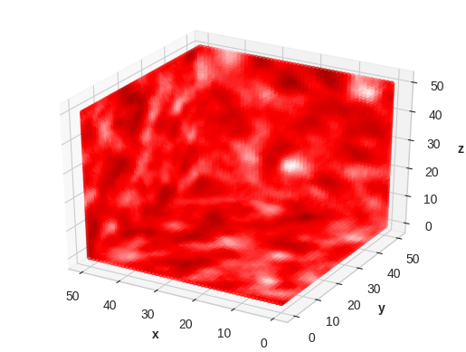

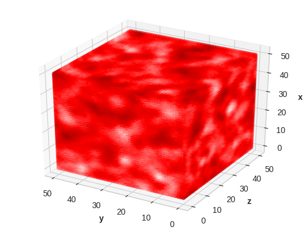

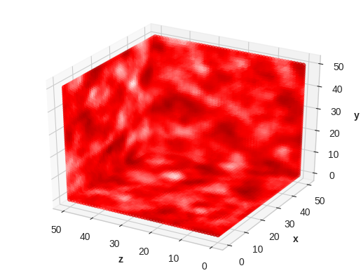

## Slices along x,y and z

Sliced x-wise

Sliced y-wise

Sliced z-wise

0/51

0/51

0/51

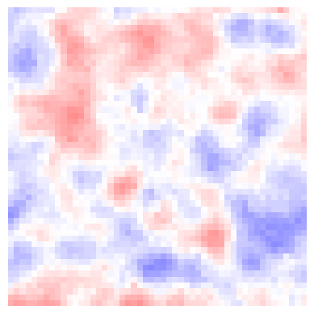

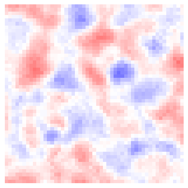

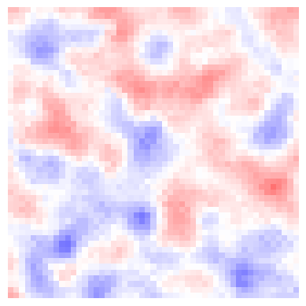

1/51

1/51

1/51

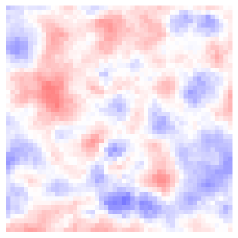

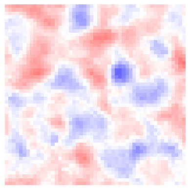

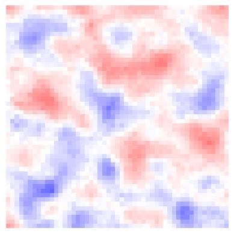

2/51

2/51

2/51

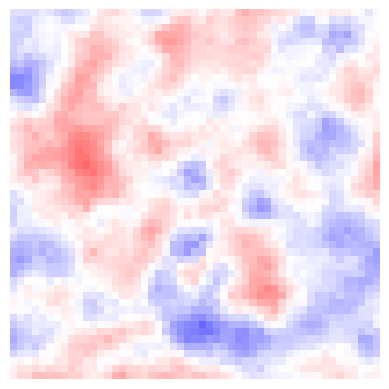

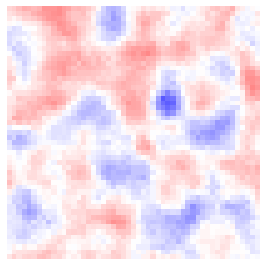

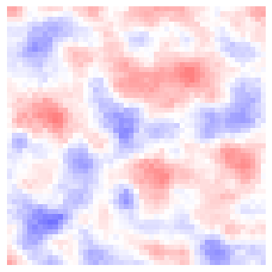

3/51

3/51

3/51

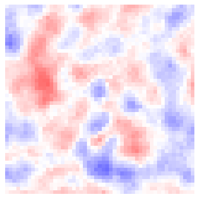

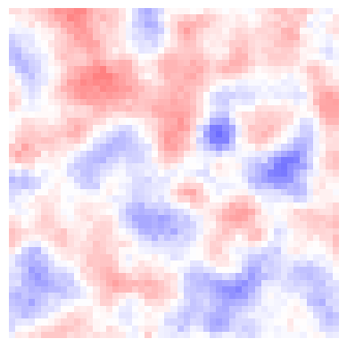

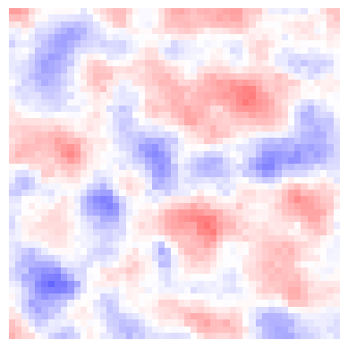

4/51

4/51

4/51

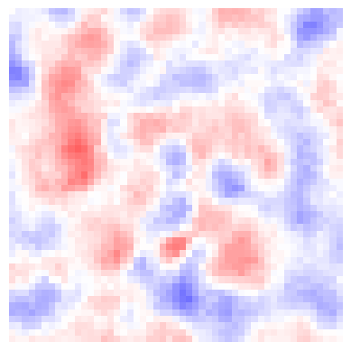

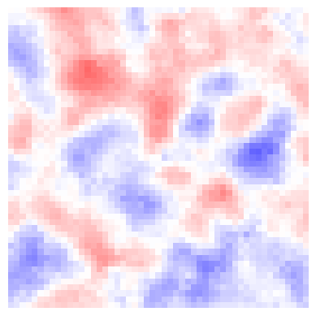

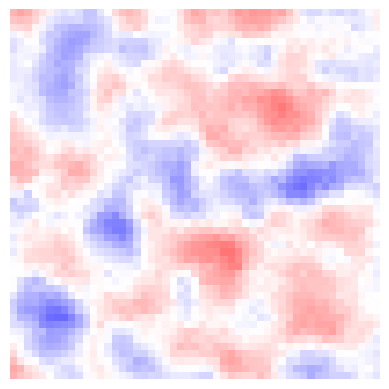

5/51

5/51

5/51

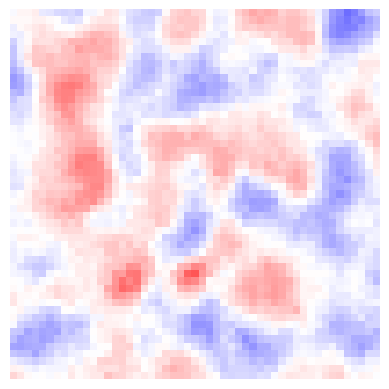

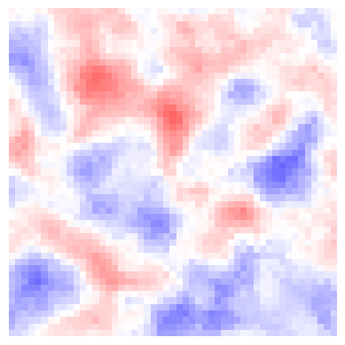

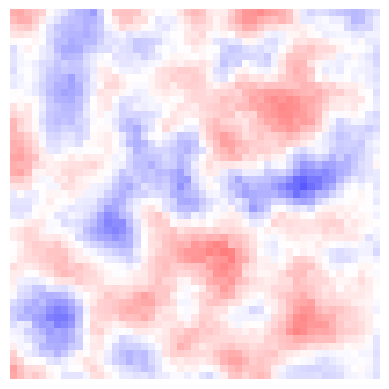

6/51

6/51

6/51

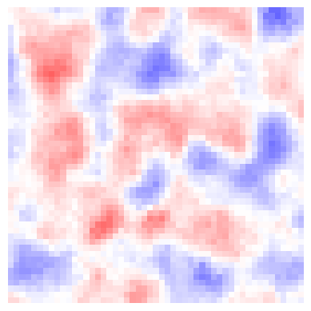

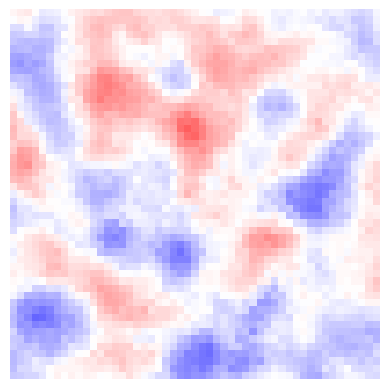

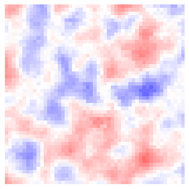

7/51

7/51

7/51

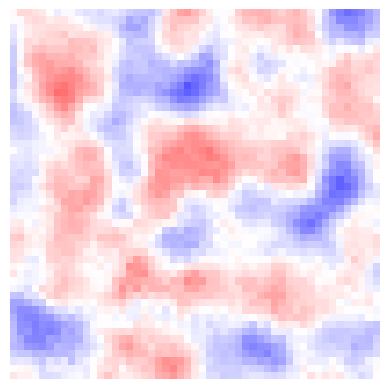

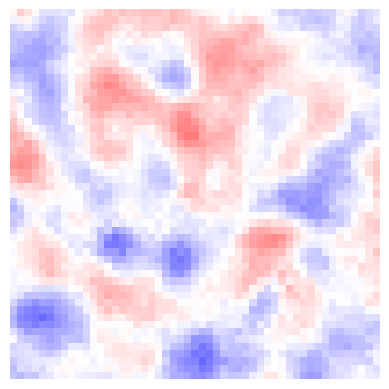

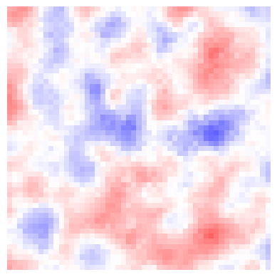

8/51

8/51

8/51

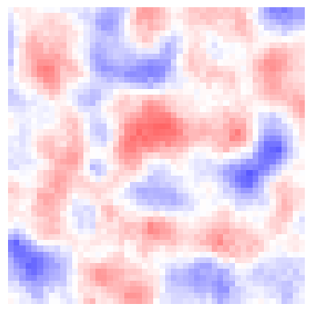

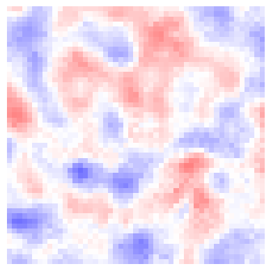

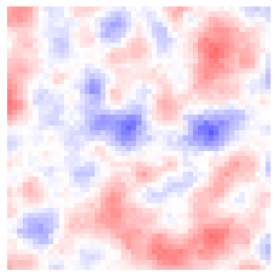

9/51

9/51

9/51

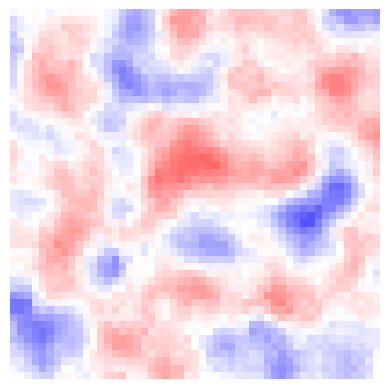

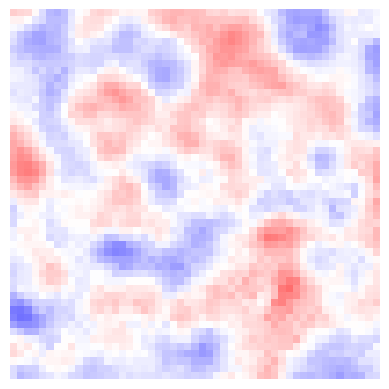

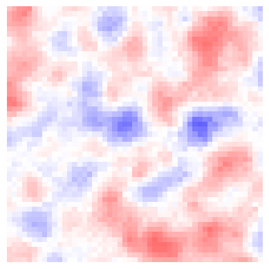

10/51

10/51

10/51

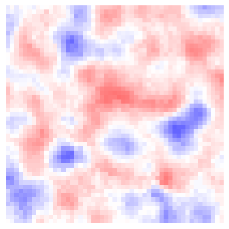

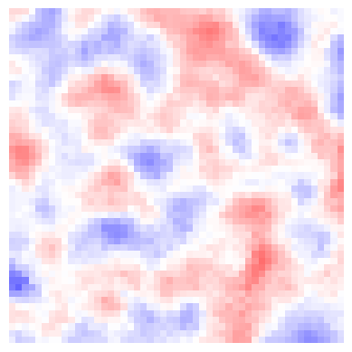

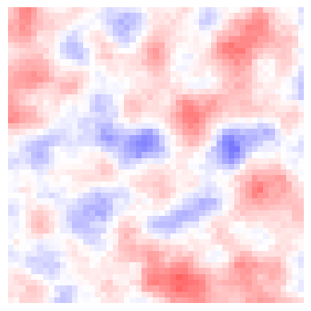

11/51

11/51